# A mathematical model for behavior of radiotracer in a PET flow phantom

### First we need to import libraries for the analysis:

Numpy is a numerical library that provides mathematical tools for python. Matplotlib is used for plotting and pandas is used for dataframe manipulation. Scipy is a library that provides algorithms for optimization, integration, interpolation, eigenvalue problems, algebraic equations, differential equations, statistics and many other classes of problems. From scipy we only need functions for optimization and interpolation.

We also have created a python module called functions where we define more functions. We explain aforementioned functions as we use them but you can also view the source code in the same source as this notebook.

```python
import numpy as np
import matplotlib.pyplot as plt
import matplotlib.patches as mpatches
import pandas as pd
from scipy.interpolate import interp1d
import scipy.optimize as optimize
from functions import *
```

### Importing data

The data is provided in one Excel-file that has multiple sheets. We need to iterate through all of the sheets and save the data from each one of the sheets to the pandas dataframe for easier access. In the loop we iterate through all of the sheets, add them to a list of dataframes and in the end combine all six of the dataframes into one main dataframe.

We are also defining a new variable in the dataframe called midpoint. Midpoint is a real value that is defined as the midwaypoint between the time_start and the time_end timestamps.

```python
data = pd.read_excel("/home/mikael/Documents/SMAT_projekti/TACs.xlsx", sheet_name=None)
relevant_keys = ['PT 300 ml Qclear 2', 'PT 300 ml Qclear 1', 'PT 200 ml Qclear 2', 'PT 200 ml Qclear 1', 'PT 100 ml Qclear 2', 'PT 100 ml Qclear 1']
samples = [2, 1, 2, 1, 2, 1]
flows = [300, 300, 200, 200, 100, 100]
frames = []

for key, sample, flow in zip(relevant_keys, samples, flows):
    frame = data[key]
    df = frame.loc[5:]
    df.columns = ["time", "input", "tissue"]
    df[['time_start', 'time_end']] = df['time'].str.split(' - ', 1, expand=True)
    df = df.assign(sample=sample, flow=flow)
    df = df.astype({'input': 'float64', 'tissue': 'float64', 'time_start': 'int32', 'time_end': 'int32'})
    df = df.drop(["time"], axis=1)
    df["midpoint"] = (df["time_end"] + df["time_start"]) / 2
    frames.append(df)
df = pd.concat(frames)
df
```

|  | input | tissue | time_start | time_end | sample | flow | midpoint |
| --- | --- | --- | --- | --- | --- | --- | --- |
| 5 | 1.456478e+03 | 407.96191 | 0 | 5 | 2 | 300 | 2.5 |
| 6 | 1.278932e+03 | 459.05683 | 5 | 10 | 2 | 300 | 7.5 |
| 7 | 2.265328e+04 | 646.44457 | 10 | 15 | 2 | 300 | 12.5 |
| 8 | 4.574733e+05 | 10505.08901 | 15 | 20 | 2 | 300 | 17.5 |
| 9 | 1.643083e+06 | 89934.22971 | 20 | 25 | 2 | 300 | 22.5 |
| ... | ... | ... | ... | ... | ... | ... | ... |
| 24 | 1.392625e+06 | 784895.39999 | 140 | 160 | 1 | 100 | 150.0 |
| 25 | 6.902623e+05 | 925024.12368 | 160 | 190 | 1 | 100 | 175.0 |
| 26 | 2.563172e+05 | 870937.93689 | 190 | 220 | 1 | 100 | 205.0 |
| 27 | 7.789175e+04 | 634442.87209 | 220 | 250 | 1 | 100 | 235.0 |
| 28 | 2.397860e+04 | 369306.60994 | 250 | 280 | 1 | 100 | 265.0 |

144 rows × 7 columns

### Creating more features

In our model we are going to need more features than we have in the dataset. We are needing the timepoint where the input curve reaches it's maximum value. We also need to calculate the integral for the tissue curve as we are going to normalize it so the optimization problem becomes easier later on.

We group the dataframe by different flow and sample values and calculate aforementioned values for each of the subdataframes. In the end we create a pandas dataframe from our dictionary and merge it with our original dataframe.

```python
feature_df = {
    "flow": [],
    "sample": [],
    "tissue_integral": [],
    "input_x_max": [],
    "tissue_x_max": []
}

for name, group in df.groupby(['sample', 'flow']):
    feature_df["flow"].append(group["flow"].iloc[0])
    feature_df["sample"].append(group["sample"].iloc[0])

    # Creating interpolation out of both functions
    cubic_input = interp1d(group["midpoint"], group["input"], kind='cubic')
    cubic_tissue = interp1d(group["midpoint"], group["tissue"], kind='cubic')
    min_inter, max_inter = min(group["midpoint"]), max(group["midpoint"])

    # Finding in which timepoint the input function reaches maximum flow value
    results = optimize.minimize(lambda x: -cubic_input(x), x0=(100), bounds = [(min_inter + 1, max_inter - 1)])
    feature_df["input_x_max"].append(results["x"][0])

    # Finding in which timepoint the tissue function reaches maximum flow value
    results = optimize.minimize(lambda x: -cubic_tissue(x), x0=(100), bounds = [(min_inter + 1, max_inter - 1)])
    feature_df["tissue_x_max"].append(results["x"][0])

    # Finding the integral of the tissue function
    integral = np.trapz(group["tissue"], x=group["midpoint"])
    feature_df["tissue_integral"].append(integral)

feature_df = pd.DataFrame(feature_df)
df = pd.merge(df, feature_df, how="left", on=["flow", "sample"])
df
```

|  | input | tissue | time_start | time_end | sample | flow | midpoint | tissue_integral | input_x_max | tissue_x_max |
| --- | --- | --- | --- | --- | --- | --- | --- | --- | --- | --- |
| 0 | 1.456478e+03 | 407.96191 | 0 | 5 | 2 | 300 | 2.5 | 4.000549e+07 | 28.483992 | 47.474071 |
| 1 | 1.278932e+03 | 459.05683 | 5 | 10 | 2 | 300 | 7.5 | 4.000549e+07 | 28.483992 | 47.474071 |
| 2 | 2.265328e+04 | 646.44457 | 10 | 15 | 2 | 300 | 12.5 | 4.000549e+07 | 28.483992 | 47.474071 |
| 3 | 4.574733e+05 | 10505.08901 | 15 | 20 | 2 | 300 | 17.5 | 4.000549e+07 | 28.483992 | 47.474071 |
| 4 | 1.643083e+06 | 89934.22971 | 20 | 25 | 2 | 300 | 22.5 | 4.000549e+07 | 28.483992 | 47.474071 |
| ... | ... | ... | ... | ... | ... | ... | ... | ... | ... | ... |
| 139 | 1.392625e+06 | 784895.39999 | 140 | 160 | 1 | 100 | 150.0 | 1.091706e+08 | 118.793711 | 182.669720 |
| 140 | 6.902623e+05 | 925024.12368 | 160 | 190 | 1 | 100 | 175.0 | 1.091706e+08 | 118.793711 | 182.669720 |
| 141 | 2.563172e+05 | 870937.93689 | 190 | 220 | 1 | 100 | 205.0 | 1.091706e+08 | 118.793711 | 182.669720 |
| 142 | 7.789175e+04 | 634442.87209 | 220 | 250 | 1 | 100 | 235.0 | 1.091706e+08 | 118.793711 | 182.669720 |
| 143 | 2.397860e+04 | 369306.60994 | 250 | 280 | 1 | 100 | 265.0 | 1.091706e+08 | 118.793711 | 182.669720 |

144 rows × 10 columns

Now we are creating a new variable called scaled_tissue. Scaled_tissue is the value of the tissue function divided (scaled) by it's total integral.

```python
df["scaled_tissue"] = df["tissue"] / df["tissue_integral"]
```

### Sampling from original dataset:

```python
sampled_dict = {
    "x": [],
    "ss_tissue": [],
    "s_tissue": [],
    "sample": [],
    "flow": []
}

num_samples = 500
for name, group in df.groupby(['sample', 'flow']):
    results = get_interpolated_sample(
        min(df["midpoint"]),
        max(df["midpoint"]),
        group,
        num_samples,
        ["scaled_tissue", "tissue"],
        "midpoint"
    )
    sampled_dict["x"].append(results[0])
    sampled_dict["ss_tissue"].append(results[1][0])
    sampled_dict["s_tissue"].append(results[1][1])
    sampled_dict["sample"].append(np.repeat(group["sample"].iloc[0], num_samples))
    sampled_dict["flow"].append(np.repeat(group["flow"].iloc[0], num_samples))

open_list = lambda x: [item for sublist in x for item in sublist]

for key in sampled_dict.keys():
    sampled_dict[key] = open_list(sampled_dict[key])

sampled_df = pd.DataFrame(sampled_dict)
sampled_df = pd.merge(sampled_df, feature_df, how="inner", on=["sample", "flow"])
sampled_df
```

|  | x | ss_tissue | s_tissue | sample | flow | tissue_integral | input_x_max | tissue_x_max |
| --- | --- | --- | --- | --- | --- | --- | --- | --- |
| 0 | 2.500000 | 0.000012 | 1267.153700 | 1 | 100 | 1.091706e+08 | 118.793711 | 182.669720 |
| 1 | 3.026052 | 0.000012 | 1272.243678 | 1 | 100 | 1.091706e+08 | 118.793711 | 182.669720 |
| 2 | 3.552104 | 0.000012 | 1277.155441 | 1 | 100 | 1.091706e+08 | 118.793711 | 182.669720 |
| 3 | 4.078156 | 0.000012 | 1281.909044 | 1 | 100 | 1.091706e+08 | 118.793711 | 182.669720 |
| 4 | 4.604208 | 0.000012 | 1286.524541 | 1 | 100 | 1.091706e+08 | 118.793711 | 182.669720 |
| ... | ... | ... | ... | ... | ... | ... | ... | ... |
| 2995 | 262.895792 | 0.000034 | 1360.482562 | 2 | 300 | 4.000549e+07 | 28.483992 | 47.474071 |
| 2996 | 263.421844 | 0.000034 | 1357.702401 | 2 | 300 | 4.000549e+07 | 28.483992 | 47.474071 |
| 2997 | 263.947896 | 0.000034 | 1354.824264 | 2 | 300 | 4.000549e+07 | 28.483992 | 47.474071 |
| 2998 | 264.473948 | 0.000034 | 1351.845891 | 2 | 300 | 4.000549e+07 | 28.483992 | 47.474071 |
| 2999 | 265.000000 | 0.000034 | 1348.765020 | 2 | 300 | 4.000549e+07 | 28.483992 | 47.474071 |

3000 rows × 8 columns

We could set different weightings for errors so the optimization function penalizes some errors more than the others. This allows us to fit the function for the curve better in some places for the cost of fit being worse on other parts of the curve. For now the weighting is set to same weighting for all parts of the curve.

```python
#sampled_df["error_weigth"] = np.where(((sampled_df["x"] < sampled_df["tissue_x_max"]) & (sampled_df["flow"] == 100) & (sampled_df["sample"] == 1)), 1,  2000)
sampled_df["error_weight"] = 1
```

### Fitting the nonparametric functions

Now we are fitting the Exponentially modified Gaussian to each datagroup. First we find the mu, sigma and lambda parameters from the scaled values. After we have found those three parameters we are trying to find a scaling factor h so the scaled distribution matches the original function. The reason for this is the optimization problem behaves much better with 3 + 1 parameters than trying to find all three at once. The optimization is quite sensitive to the initial values and experimenting with different values may lead to different results.

Also we are creating a plot in the same loop so we can see how the function fits for each one of the datagroups.

|  | flow | sample | mu | mu_x | lambda_ | sigma | h | tissue_integral | input_x_max | tissue_x_max |
| --- | --- | --- | --- | --- | --- | --- | --- | --- | --- | --- |
| 0 | 100 | 1 | 164.904198 | 4.611049 | 0.036358 | 47.988008 | 1.052938e+06 | 1.091706e+08 | 118.793711 | 182.669720 |
| 1 | 100 | 2 | 104.594668 | 4.600794 | 0.033962 | 47.986230 | 7.761716e+05 | 8.881070e+07 | 58.586732 | 123.186942 |
| 2 | 200 | 1 | 65.316090 | 3.599998 | 0.038874 | 20.967020 | 1.166782e+06 | 6.020789e+07 | 47.316101 | 78.880157 |
| 3 | 200 | 2 | 66.214115 | 3.599836 | 0.040948 | 20.966978 | 1.189872e+06 | 6.188868e+07 | 48.214937 | 78.895128 |
| 4 | 300 | 1 | 36.583267 | 2.399795 | 0.041720 | 10.929142 | 1.453718e+06 | 3.891364e+07 | 28.583950 | 47.416007 |
| 5 | 300 | 2 | 36.483384 | 2.399818 | 0.041219 | 10.929165 | 1.492890e+06 | 4.000549e+07 | 28.483992 | 47.474071 |

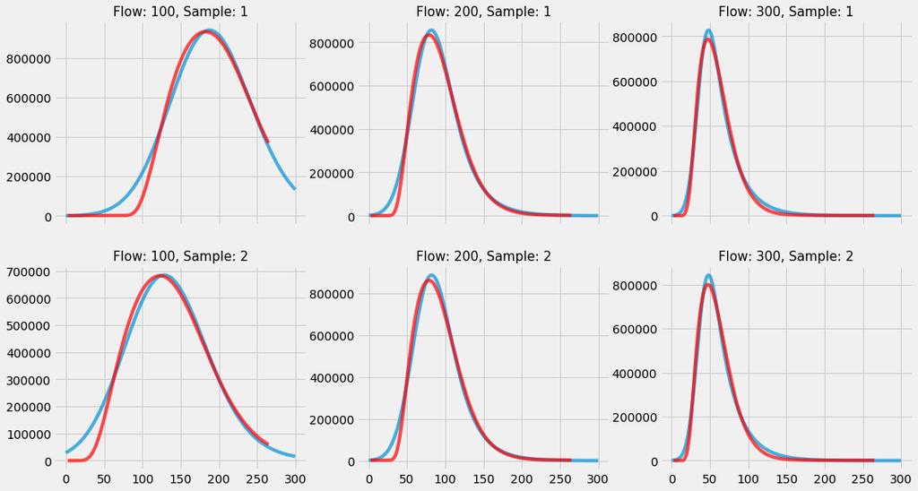

```python
groups = sampled_df.groupby(["flow", "sample"]) # NON PARAMETRIC

plt.style.use("fivethirtyeight")

results_dict = {
    "flow": [],
    "sample": [],
    "mu": [],
    "mu_x": [],
    "lambda_": [],
    "sigma": [],
    "h": []
}

initial_values = [
        [2.4, 11, 0.041], # 300 alkuarvaus
        [4.6, 48, 0.022], # 100, 2
        [4.6, 48, 0.027], # 100, 1
        [3.6, 21, 0.041]
    ]

fig, axs = plt.subplots(2, 3, sharex=True, figsize=(16, 9))
for i, group in groups:
    if i[0] == 100:
        if i[1] == 1:
            initial_value = initial_values[2]
        else:
            initial_value = initial_values[1]
    elif i[0] == 300:
        initial_value = initial_values[0]
    elif i[0] == 200:
        initial_value = initial_values[3]
    mu_x_initial_value, sigma_initial_value, lambda_initial_value = initial_value

    bounds = [(None, None), (1e-5, None), (1e-5, None), (None, None)]

    x_0 = [mu_x_initial_value, sigma_initial_value, lambda_initial_value, 1]
    res1 = scipy.optimize.minimize(EMG_loss, args=group, x0=x_0, bounds=bounds)
    x_range = np.linspace(0, 300, 900)
    mu = (group["input_x_max"] + res1["x"][0] * 1000 / group["flow"]).iloc[0]
    sigma = res1["x"][1]
    lambda_ = res1["x"][2]

    emg_params = {
        "mu_x": res1["x"][0],
        "sigma": sigma,
        "lambda_": lambda_
    }

    res2 = scipy.optimize.minimize(EMG_loss_h, args=(group, emg_params), x0=[80000])
    h = res2["x"][0]


    pred_y = EMG(x_range, mu, sigma, lambda_, h)

    # Plotting:
    row, column = i[1] - 1, int(i[0] / 100 - 1)

    axs[row, column].set_title(f"Flow: {i[0]}, Sample: {i[1]}", fontsize=15)
    axs[row, column].plot(x_range, pred_y, alpha=0.7)
    axs[row, column].plot(group["x"], group["s_tissue"], color="r", alpha=0.7)

    # Creating results dictionary
    results_dict["flow"].append(group["flow"].iloc[0])
    results_dict["sample"].append(group["sample"].iloc[0])
    results_dict["mu"].append(mu)
    results_dict["mu_x"].append(res1["x"][0])
    results_dict["sigma"].append(sigma)
    results_dict["lambda_"].append(lambda_)
    results_dict["h"].append(h)

results_df = pd.DataFrame(results_dict)
results_df = results_df.merge(feature_df, how="inner", on=["flow", "sample"])
results_df
```

Above we can see that the function is not a perfect fit in the earlier part of the curve, but the primary interest is the later part of the curve. In all of the cases we have almost perfect fit after the tissue function has reached its maximum value.

### Examining fit parameters.

Later parts of this analysis rely heavily on the functions.py file. If you are more interested in the code behind the plots please refer to aforementioned python file for more information. In the next step we are creating a param_dict where you can specify the order of the polynomial that we are going to fit to the parameters.

```python
param_dict = {
    "mu_x_count": 1,
    "sigma_count": 2,
    "lambda_count": 2,
    "h_count": 1
}
```

Here we specified that we want to model mu_x with linear model, sigma with second order polynomial etc. Calling plot_all_params with the results dataframe and parameter dictionary returns a plot where you can see how each one of the parameters relates to the flow.

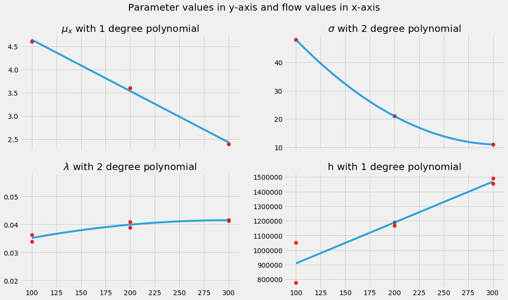

```python
plot_all_params(results_df, param_dict, True)
```

The h parameter varies quite a lot with the flow value of 100. We are going to see this later on in the results. We could find another model for the h that doesn't use the flow as a parameter but because our sample size is so small we decided to stick with this model. One could improve this model and results by getting more samples for the 100 flow values and see if this is just a random error or if the flow is a bad predictor of h.

To get predictions for our original data we are going to use function defined in the functions.py called plot_against_predictions_all. It is going to take results dataframe, original dataframe and the parameter dict as input and will plot predictions against the original values.

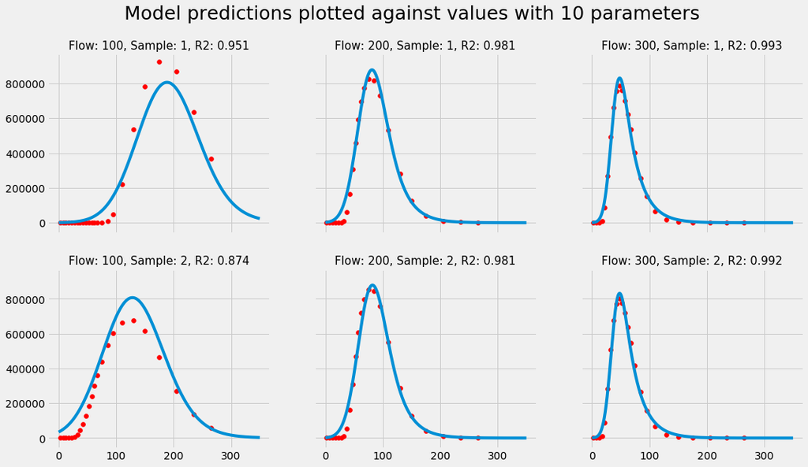

```python
plot_against_predictions_all(results_df, df, param_dict, True)
```

In the plot above we can see that model fits nearly perfectly for all the curves except when the flow is 100. Even with the problem with h parameter the right tail of the distribution fits the curve very good. The right tail was the more interesting part of the function

### Comparing to the previous model

We have the values that the original one compartment model predicted in the CarimasFit excel spreadsheet. We are loading the data similarly as we did in the start of this notebook.

```python
data = pd.read_excel("/home/mikael/Documents/SMAT_projekti/CarimasFit.xlsx", sheet_name=None)
samples = [2, 1, 2, 1, 2, 1]
flows = [300, 300, 200, 200, 100, 100]
frames = []

for sample, flow in zip(samples, flows):
    key = f"{flow}_QC{sample}"
    frame = data[key]
    frame = frame.loc[5:26]
    frame.columns = ["time_start", "time_end", "fit_input", "input", "fit_tissue", "tissue"]
    frame = frame.astype({'input': 'float64', 'tissue': 'float64', 'time_start': 'float64', 'time_end': 'float64', 'fit_tissue': 'float64', 'fit_input': 'float64'})
    frame = frame.astype({'time_start': 'int32', 'time_end': 'int32'})
    frame = frame.assign(sample=sample, flow=flow)
    frame["midpoint"] = (frame["time_end"] + frame["time_start"]) / 2
    frames.append(frame)
dif_fit_df = pd.concat(frames)
dif_fit_df
```

|  | time_start | time_end | fit_input | input | fit_tissue | tissue | sample | flow | midpoint |
| --- | --- | --- | --- | --- | --- | --- | --- | --- | --- |
| 5 | 10 | 15 | 2.265328e+04 | 2.265328e+04 | 1616.564502 | 646.444572 | 2 | 300 | 12.5 |
| 6 | 15 | 20 | 4.574733e+05 | 4.574733e+05 | 30309.386782 | 10505.089005 | 2 | 300 | 17.5 |
| 7 | 20 | 25 | 1.643083e+06 | 1.643083e+06 | 152548.711006 | 89934.229711 | 2 | 300 | 22.5 |
| 8 | 25 | 30 | 2.379859e+06 | 2.379859e+06 | 373271.144190 | 283218.516498 | 2 | 300 | 27.5 |
| 9 | 30 | 35 | 2.137931e+06 | 2.137931e+06 | 592532.851887 | 508631.266407 | 2 | 300 | 32.5 |
| ... | ... | ... | ... | ... | ... | ... | ... | ... | ... |
| 22 | 140 | 160 | 1.392625e+06 | 1.392625e+06 | 805875.518269 | 784895.399989 | 1 | 100 | 150.0 |
| 23 | 160 | 190 | 6.902623e+05 | 6.902623e+05 | 856778.673194 | 925024.123684 | 1 | 100 | 175.0 |
| 24 | 190 | 220 | 2.563172e+05 | 2.563172e+05 | 766403.231412 | 870937.936887 | 1 | 100 | 205.0 |
| 25 | 220 | 250 | 7.789175e+04 | 7.789175e+04 | 623299.934882 | 634442.872087 | 1 | 100 | 235.0 |
| 26 | 250 | 280 | 2.397860e+04 | 2.397860e+04 | 486273.402136 | 369306.609940 | 1 | 100 | 265.0 |

132 rows × 9 columns

Defining the error metric function and the coefficient of determination. We are usign Root mean squared as our error function when comparing models and R2 as general goodness of fit metric.

```python
def RMSE(y, y_pred):
    return np.sqrt(np.mean((y - y_pred) ** 2))

def R2(y, y_pred):
    tss = np.sum((y - np.mean(y)) ** 2)
    rss = np.sum((y - y_pred) ** 2)
    return 1 - rss / tss
```

Now we are looping over all the groups of data in the both models, calculating the metrics we are interested and appending them to the dictionary that we are transforming to a dataframe.

```python
comparison_dict = {
    "flow": [],
    "sample": [],
    "model": [],
    "RMSE": [],
    "R2": []
}

for i, group in dif_fit_df.groupby(["flow", "sample"]):
    rmse = RMSE(group["tissue"], group["fit_tissue"])
    r2 = R2(group["tissue"], group["fit_tissue"])
    comparison_dict["flow"].append(i[0])
    comparison_dict["sample"].append(i[1])
    comparison_dict["model"].append("1TCM")
    comparison_dict["RMSE"].append(rmse)
    comparison_dict["R2"].append(r2)

for i, group in df.groupby(["flow", "sample"]):
    flow, sample = i
    new_parameter_dict = get_model_params(flow=flow, results_df = results_df, parameter_dict=param_dict)
    mu = (group["input_x_max"] + new_parameter_dict["mu_x"] * 1000 / flow).iloc[0]
    emg_vals = EMG(group["midpoint"], mu, new_parameter_dict["sigma"], new_parameter_dict["lambda_"], new_parameter_dict["h"])
    rmse = RMSE(group["tissue"], emg_vals)
    r2 = R2(group["tissue"], emg_vals)
    comparison_dict["flow"].append(i[0])
    comparison_dict["sample"].append(i[1])
    comparison_dict["model"].append("EMG_model")
    comparison_dict["RMSE"].append(rmse)
    comparison_dict["R2"].append(r2)

comparison_df = pd.DataFrame(comparison_dict)
comparison_df
```

|  | flow | sample | model | RMSE | R2 |
| --- | --- | --- | --- | --- | --- |
| 0 | 100 | 1 | 1TCM | 44190.153792 | 0.980650 |
| 1 | 100 | 2 | 1TCM | 61089.278973 | 0.932906 |
| 2 | 200 | 1 | 1TCM | 60174.447926 | 0.963032 |
| 3 | 200 | 2 | 1TCM | 60602.120845 | 0.964900 |
| 4 | 300 | 1 | 1TCM | 49028.469213 | 0.973382 |
| 5 | 300 | 2 | 1TCM | 50182.380872 | 0.973186 |
| 6 | 100 | 1 | EMG_model | 68467.512501 | 0.950937 |
| 7 | 100 | 2 | EMG_model | 84121.371763 | 0.874397 |
| 8 | 200 | 1 | EMG_model | 42981.403449 | 0.980819 |
| 9 | 200 | 2 | EMG_model | 44179.777722 | 0.981001 |
| 10 | 300 | 1 | EMG_model | 25304.876313 | 0.992858 |
| 11 | 300 | 2 | EMG_model | 26955.092271 | 0.992213 |

Now we are plotting the values for easy comparison. We can see that the RMSE is higher (worse) where flow is 100 but much lower on all of the other samples.

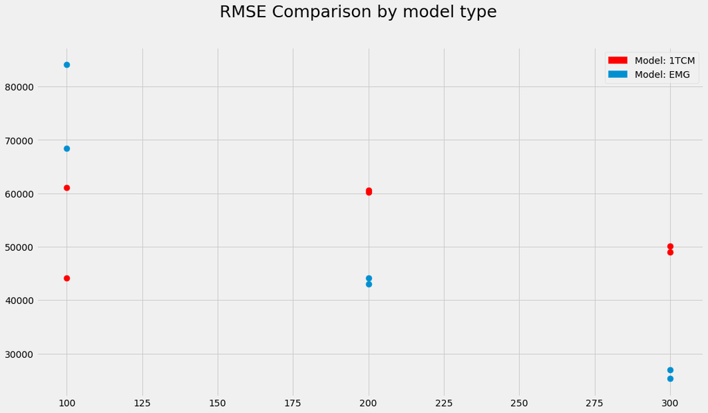

```python
fig, ax = plt.subplots(figsize=(16, 9))
for i, group in comparison_df.groupby(["flow", "sample", "model"]):
    if i[2] == "1TCM":
        ax.scatter(i[0], group["RMSE"], color="r", s=80, label=f"Model: {i[2]}")
    else:
        ax.scatter(i[0], group["RMSE"], color="#0090d1", s=80, label=f"Model: {i[2]}")
ax.legend()
red_patch = mpatches.Patch(color='red', label='Model: 1TCM')
blue_patch = mpatches.Patch(color='#0090d1', label='Model: EMG')
ax.legend(handles=[red_patch, blue_patch])

fig.suptitle("RMSE Comparison by model type", fontsize=25)
plt.savefig("rmse_comparison.png")
```

Now we are comparing the RMSE values of the two different models. Below we are grouping the RMSE by model and flow and then calculating how much our RMSE increased or decreased compared to the previous differential equation model.

```python
rmse_by_flow = comparison_df.groupby(["model", "flow"])["RMSE"].mean().values
pct_increase = lambda new, og: str(round((new - og) / og * 100, 1)) + " %"

for old, new in zip(rmse_by_flow[0:3], rmse_by_flow[3:6]):
    print(pct_increase(new, old))
```

```
44.9 %
-27.8 %
-47.3 %
```

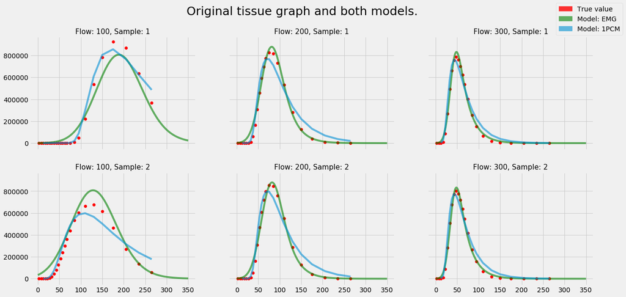

```python
plot_both_models(results_df, df, param_dict, dif_fit_df, save=False)
```

We see that Exponentially modified gaussian model fits almost perfectly with 200 and 300 flow values. In the 100 flow the EMG over/underestimates the peak of the distribution but the tail is still pretty accurately predicted.